# U.S. Medical Insurance Costs

Codecademy provides students with the U.S. Medical Insurance Costs dataset to build a portfolio.

```python
import pandas as pd

# Load the data from the insurance.csv file into a DataFrame
data = pd.read_csv('insurance.csv')

#Display all data
data
```

|  | age | sex | bmi | children | smoker | region | charges |
| --- | --- | --- | --- | --- | --- | --- | --- |
| 0 | 19 | female | 27.900 | 0 | yes | southwest | 16884.92400 |
| 1 | 18 | male | 33.770 | 1 | no | southeast | 1725.55230 |
| 2 | 28 | male | 33.000 | 3 | no | southeast | 4449.46200 |
| 3 | 33 | male | 22.705 | 0 | no | northwest | 21984.47061 |
| 4 | 32 | male | 28.880 | 0 | no | northwest | 3866.85520 |
| ... | ... | ... | ... | ... | ... | ... | ... |
| 1333 | 50 | male | 30.970 | 3 | no | northwest | 10600.54830 |
| 1334 | 18 | female | 31.920 | 0 | no | northeast | 2205.98080 |
| 1335 | 18 | female | 36.850 | 0 | no | southeast | 1629.83350 |
| 1336 | 21 | female | 25.800 | 0 | no | southwest | 2007.94500 |
| 1337 | 61 | female | 29.070 | 0 | yes | northwest | 29141.36030 |

1338 rows × 7 columns

```python
# Display the first few rows of the data
data.head()
```

|  | age | sex | bmi | children | smoker | region | charges |
| --- | --- | --- | --- | --- | --- | --- | --- |
| 0 | 19 | female | 27.900 | 0 | yes | southwest | 16884.92400 |
| 1 | 18 | male | 33.770 | 1 | no | southeast | 1725.55230 |
| 2 | 28 | male | 33.000 | 3 | no | southeast | 4449.46200 |
| 3 | 33 | male | 22.705 | 0 | no | northwest | 21984.47061 |
| 4 | 32 | male | 28.880 | 0 | no | northwest | 3866.85520 |

# Questions from Coursera:

#### 1. Find out the average age of the patients in the dataset.

```python
# Calculate the average age of the patients
average_age = data['age'].mean()
average_age
```

```
39.20702541106129
```

```python
# Calculate the average age of the patients and round to the nearest whole number
average_age = round(data['age'].mean())
average_age
```

```
39
```

**Answer:** 39

#### 2. Analyse where a majority of the individuals are from.

```python
# Count the number of individuals from each region
region_counts = data['region'].value_counts()
region_counts
```

```
southeast    364
southwest    325
northwest    325
northeast    324
Name: region, dtype: int64
```

**Answer:** Southeast with a total of 364

#### 3. Look at the different costs between smokers vs. non-smokers.

```python
# Compare the charges for smokers vs. non-smokers
smoker_charges = data.groupby('smoker')['charges'].mean()
smoker_charges
```

```
smoker
no      8434.268298
yes    32050.231832
Name: charges, dtype: float64
```

```python
# Compare the charges for smokers vs. non-smokers and round to the nearest whole number
smoker_charges = round(data.groupby('smoker')['charges'].mean())
smoker_charges
```

```
smoker
no      8434.0
yes    32050.0
Name: charges, dtype: float64
```

#### 4. Figure out what the average age is for someone who has at least one child in this data set.

```python
# Calculate the average age of individuals who have at least one child
average_age_with_child = data[data['children'] >= 1]['age'].mean()
average_age_with_child
```

```
39.78010471204188
```

```python
# Calculate the average age of individuals who have at least one child and round to the nearest whole number
average_age_with_child = round(data[data['children'] >= 1]['age'].mean())
average_age_with_child
```

```
40
```

**Answer:** 40

# Extra Analysis by myself

## Using a regression analysis and predictive models to determine factors that influence insurance charges

```python
# Generate descriptive statistics for the different variables
data.describe(include='all')
```

|  | age | sex | bmi | children | smoker | region | charges |
| --- | --- | --- | --- | --- | --- | --- | --- |
| count | 1338.000000 | 1338 | 1338.000000 | 1338.000000 | 1338 | 1338 | 1338.000000 |
| unique | NaN | 2 | NaN | NaN | 2 | 4 | NaN |
| top | NaN | male | NaN | NaN | no | southeast | NaN |
| freq | NaN | 676 | NaN | NaN | 1064 | 364 | NaN |
| mean | 39.207025 | NaN | 30.663397 | 1.094918 | NaN | NaN | 13270.422265 |
| std | 14.049960 | NaN | 6.098187 | 1.205493 | NaN | NaN | 12110.011237 |
| min | 18.000000 | NaN | 15.960000 | 0.000000 | NaN | NaN | 1121.873900 |
| 25% | 27.000000 | NaN | 26.296250 | 0.000000 | NaN | NaN | 4740.287150 |
| 50% | 39.000000 | NaN | 30.400000 | 1.000000 | NaN | NaN | 9382.033000 |
| 75% | 51.000000 | NaN | 34.693750 | 2.000000 | NaN | NaN | 16639.912515 |
| max | 64.000000 | NaN | 53.130000 | 5.000000 | NaN | NaN | 63770.428010 |

```python
# Calculate the correlation between the different variables and the insurance charges
correlations = data.corr()['charges'].sort_values()
correlations
```

```
children    0.067998
bmi         0.198341
age         0.299008
charges     1.000000
Name: charges, dtype: float64
```

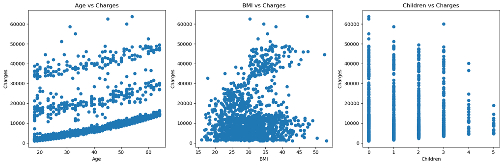

```python
import matplotlib.pyplot as plt

# Create scatter plots for the numerical variables
plt.figure(figsize=(15, 5))

plt.subplot(1, 3, 1)
plt.scatter(data['age'], data['charges'])
plt.title('Age vs Charges')
plt.xlabel('Age')
plt.ylabel('Charges')

plt.subplot(1, 3, 2)
plt.scatter(data['bmi'], data['charges'])
plt.title('BMI vs Charges')
plt.xlabel('BMI')
plt.ylabel('Charges')

plt.subplot(1, 3, 3)
plt.scatter(data['children'], data['charges'])
plt.title('Children vs Charges')
plt.xlabel('Children')
plt.ylabel('Charges')

plt.tight_layout()
plt.show()
```

**Age vs Charges:** There seems to be a positive correlation betwen age and charges, which aligns with our correlation analysis. As age increases, the insurance charges also tend to increase.

**BMI vs Charges:** There is a less clear pattern between BMI and Charges, but it seems that higher charges are common among individuals with highe BMI.

**Children vs Charges:** There doesn't seem to be a strong relationship between the number of children and charges.

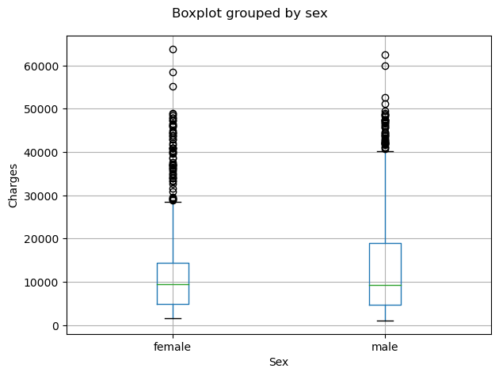

```python
# Create box plots for the categorical variables
data.boxplot(column='charges', by='sex')
plt.title('')
plt.xlabel('Sex')
plt.ylabel('Charges')

plt.tight_layout()
plt.show()
```

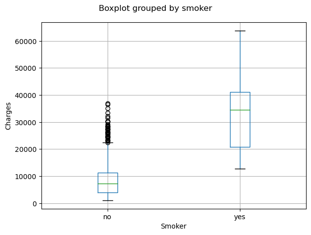

```python
data.boxplot(column='charges', by='smoker')
plt.title('')
plt.xlabel('Smoker')
plt.ylabel('Charges')

plt.tight_layout()
plt.show()
```

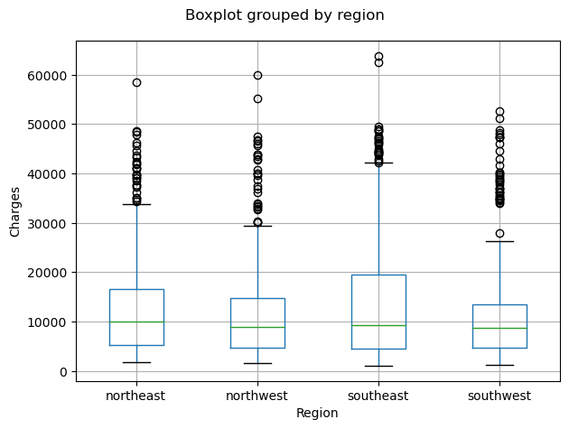

```python
data.boxplot(column='charges', by='region')
plt.title('')
plt.xlabel('Region')
plt.ylabel('Charges')

plt.tight_layout()
plt.show()
```

**Sex vs Charges:** There doesn't seem to be a significant difference in charges between males and females.

**Smoker vs charges:** There is a clear difference in charges between smokers and non-smokers. Smokers tend to have much higher charges.

**Region vs Charges:** There doesn't seem to be a significant difference in charges between the different region.

# Regression Models

#### I build multiple regression models to quantify the relationships between the variables and the insurance charges. This will allow us to identify the most significant factors. However, before we can do this, we need to convert the categorical variables into numerical form.

#### Below is a new code cell to the notebook to perform this conversion.

```python
from sklearn.preprocessing import LabelEncoder

# Create a copy of the data
data_encoded = data.copy()

# Create a label encoder
le = LabelEncoder()

# Convert the categorical variables into numerical form
data_encoded['sex'] = le.fit_transform(data_encoded['sex'])
data_encoded['smoker'] = le.fit_transform(data_encoded['smoker'])
data_encoded['region'] = le.fit_transform(data_encoded['region'])

data_encoded.head()
```

|  | age | sex | bmi | children | smoker | region | charges |
| --- | --- | --- | --- | --- | --- | --- | --- |
| 0 | 19 | 0 | 27.900 | 0 | 1 | 3 | 16884.92400 |
| 1 | 18 | 1 | 33.770 | 1 | 0 | 2 | 1725.55230 |
| 2 | 28 | 1 | 33.000 | 3 | 0 | 2 | 4449.46200 |
| 3 | 33 | 1 | 22.705 | 0 | 0 | 1 | 21984.47061 |
| 4 | 32 | 1 | 28.880 | 0 | 0 | 1 | 3866.85520 |

Above are the first few rows of the data after conversion

```python
from sklearn.model_selection import train_test_split
from sklearn.linear_model import LinearRegression
from sklearn.metrics import mean_squared_error, r2_score

# Define the feature variables and the target variable
X = data_encoded.drop('charges', axis=1)
y = data_encoded['charges']

# Split the data into training and test sets
X_train, X_test, y_train, y_test = train_test_split(X, y, test_size=0.2, random_state=42)

# Create a linear regression model
model = LinearRegression()

# Train the model
model.fit(X_train, y_train)

# Make predictions on the test set
y_pred = model.predict(X_test)

# Calculate the mean squared error and the R-squared value
mse = mean_squared_error(y_test, y_pred)
r2 = r2_score(y_test, y_pred)

mse, r2
```

```
(33635210.43117841, 0.7833463107364538)
```

Here are the performance metrics for the model on the test set:

Mean Squared Error (MSE): 33635210.43 R-squared (R²): 0.7833

The R-squared value indicates that approximately 78.33% of the variability in the insurance charges can be explained by the variables in our model. This suggests that the model has a relatively good fit to the data.

#### Examining the coefficients of the model to identify the most significant factors.

```python
# Get the coefficients of the model
coefficients = pd.DataFrame(model.coef_, X.columns, columns=['Coefficient'])
coefficients
```

|  | Coefficient |
| --- | --- |
| age | 257.056264 |
| sex | -18.791457 |
| bmi | 335.781491 |
| children | 425.091456 |
| smoker | 23647.818096 |
| region | -271.284266 |

The coefficients represent the change in the insurance charges for a one-unit increase in the corresponding variable, assuming all other variables are held constant.